# Homework 6

Krista Noe

4/12/2021

N-mixture modeling dataset:  
- **count.csv**: Counts from each replicate survey. Each row is a site, and each column is a replicate survey. Column names j1, j2, j3 represent each replicate survey.  
- **obs_covs.csv**: A continuous covariate associated with each replicate survey. Each row is a site, and each column is a replicate survey. Column names j1, j2, j3 represent each replicate survey.  
- **site_covs.csv**: Covariates associated with each site. Each row is a site, and each column a covariate. Column x1 is a continuous covariate, and column x2 is a categorical covariate with 4 levels: “a”, “b”, “c”, and “d”.

1. Load data and place into an unmarkedFramePCount object

```r
library(unmarked)
# count data
y <- read.csv("count.csv")
head(y)
```

```
##   j1 j2 j3
## 1  0  0  0
## 2  1  1  1
## 3  8 13 12
## 4  2  1  1
## 5  3  8  3
## 6  0  0  0
```

```r
y_mat <- as.matrix(y)


# detection covariates
p_covs <- read.csv("obs_covs.csv")
head(p_covs)
```

```
##          j1           j2         j3
## 1 0.9401255 -0.555760967 -0.3582067
## 2 2.4448899 -0.457783896  0.4253590
## 3 1.1633403  0.006345006 -0.2650346
## 4 0.7138189  0.857225770  1.5519564
## 5 2.0457416  0.077946090  1.9626749
## 6 0.7596043 -0.356677808 -0.1295560
```

```r
det_covs <- list(
  j = data.frame(p_covs[, c(1:3)])
)


# site-level covariates
site_covs <- read.csv("site_covs.csv")
head(site_covs)
```

```
##            x1 x2
## 1 -1.06733947  b
## 2 -0.98588873  a
## 3 -0.09409764  d
## 4  1.32241491  a
## 5  0.45689994  d
## 6 -0.89026419  b
```

```r
site_covs$x2 <- factor(site_covs$x2)

nmix_data <- unmarkedFramePCount(y = y_mat, # detection / non-detection
                                    siteCovs = site_covs, # site-level covs
                                    obsCovs = det_covs) # detection covariates
```

2. Fit an N-mixture model that assumes conditional detection probability is a function of the detection covariate provided, and expected abundance is a additive function of variables x1 and x2.

```r
fit <- pcount(formula = ~ j ~ x1 + x2, data = nmix_data, K = 100)
summary(fit)
```

```
##
## Call:
## pcount(formula = ~j ~ x1 + x2, data = nmix_data, K = 100)
##
## Abundance (log-scale):
##             Estimate     SE     z  P(>|z|)
## (Intercept)    0.915 0.1106  8.27 1.30e-16
## x1             0.370 0.0401  9.21 3.14e-20
## x2b           -0.161 0.1382 -1.16 2.45e-01
## x2c           -0.189 0.1522 -1.24 2.14e-01
## x2d            1.335 0.1195 11.17 5.63e-29
##
## Detection (logit-scale):
##             Estimate     SE     z  P(>|z|)
## (Intercept)    1.259 0.0925  13.6 4.01e-42
## j             -0.841 0.0639 -13.2 1.57e-39
##
## AIC: 1736.028
## Number of sites: 200
## optim convergence code: 0
## optim iterations: 46
## Bootstrap iterations: 0
```

3. Interpret the effect of x1 on the expected count at each site. Verity your interpretation in R.

```r
betas <- coef(fit)

#betas[2] is x1

p_0 <- (betas[1] + betas[2]*0 + betas[3] + betas[4] + betas[5])
p_1 <- (betas[1] + betas[2]*1 + betas[3] + betas[4] + betas[5])

p_1 - p_0
```

```
##  lam(Int)
## 0.3696188
```

```r
betas[2]
```

```
##   lam(x1)
## 0.3696188
```

```r
log(exp(p_1) / exp(p_0))
```

```
##  lam(Int)
## 0.3696188
```

```r
betas[2]
```

```
##   lam(x1)
## 0.3696188
```

There is a 0.369 unit change in log expected count for every 1-unit change in the predictor x1.

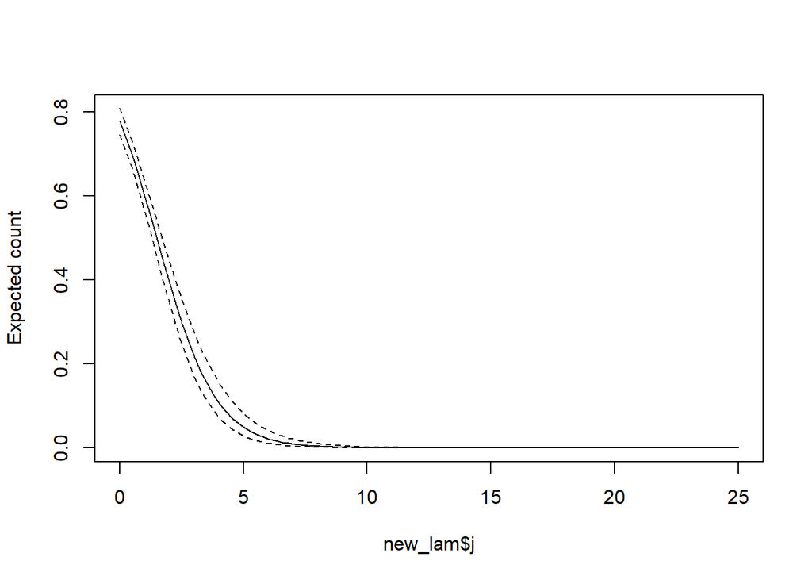

```r
new_lam <- data.frame(j = seq(min(y), max(y), length.out = 100
                              ))
#predict
prd <- predict(object = fit, newdata = new_lam, type = 'det')

#plot
plot(y = prd$Predicted, x = new_lam$j, type = 'l',
     ylim = c(0, prd[1, 'upper']),
      ylab = 'Expected count')
lines(y = prd$lower, x = new_lam$j, lty = 2)
lines(y = prd$upper, x = new_lam$j, lty = 2)
```

5. Use contrasts to compare expected abundance between all pairwise levels of variable x2. Obtain p-values associated with each contrast and tell me whether you reject or fail to reject each null hypothesis tested.

```r
betas
```

```
##   lam(Int)    lam(x1)   lam(x2b)   lam(x2c)   lam(x2d)     p(Int)       p(j)
##  0.9151447  0.3696188 -0.1606306 -0.1891303  1.3351914  1.2585992 -0.8410807
```

```r
# first make a matrix (only dealing with x2)
x <- matrix(
  c(0, 0, 1, -1, 0, #betas[3] and betas[4]
    0, 0, 1, 0, -1, #betas[3] and betas[5]
    0, 0, 0, 1, -1), #betas[4] and betas[5]
  nrow = 3, byrow = T
  )

lin_com <- linearComb(obj = fit, coefficients = x, type = 'state')

# Wald test
w <- coef(lin_com) / SE(lin_com)
w
```

```
## [1]   0.2140043 -15.9929898 -13.3713082
```

```r
# pvalues
2 * pnorm(-1 * abs(w))
```

```
## [1] 8.305437e-01 1.430000e-57 8.896230e-41
```

The contrast calculation between betas[3] and betas[4] (x2 b and c) pvalue = 8.305437e-01, therefore we fail to reject the null hypothesis at alpha level 0.05. There is not enough evidence to determine a significant difference.

The contrast calculation between betas[3] and betas[5] (x2 b and d) pvalue = 1.43e-57, therefore we reject the null hypothesis at alpha level 0.05.

The contrast calculation between betas[4] and betas[5] (x2 c and d) pvalue = 8.896230e-41, therefore we reject the null hypothesis at alpha level 0.05.